# Chapter 5 Resources and Trade: The Heckscher-Ohlin Model

# Preview

- Production possibilities
- Changing the mix of inputs
- Relationships among factor prices and goods prices, and resources and output
- Trade in the Heckscher-Ohlin model
- Factor price equalization
- Trade and income distribution
- Empirical evidence

# Introduction

- In addition to differences in labor productivity, trade occurs due to differences in resources across countries.
- The Heckscher-Ohlin theory argues that trade occurs due to differences in labor, labor skills, physical capital, capital, or other factors of production across countries.
  - Countries have different relative abundance of factors of production.
  - Production processes use factors of production with different relative intensity.

# Model of a Two-Factor Economy

# Two Factor Heckscher-Ohlin Model

1. Two countries: home and foreign.
2. Two goods: cloth and food.
3. Two factors of production: labor and capital.
4. The mix of labor and capital used varies across goods.
5. The supply of labor and capital in each country is constant and varies across countries.
6. In the long run, both labor and capital can move across sectors, equalizing their returns (wage and rental rate) across sectors.

# Production Possibilities

- With more than one factor of production, the opportunity cost in production is no longer constant and the PPF is no longer a straight line. Why?
- Numerical example:
  - $K = 3000$, total amount of capital available for production
  - $L = 2000$, total amount of labor available for production

# Production Possibilities

- Suppose use a fixed mix of capital and labor in each sector.
  - $a_{KC} = 2$, capital used to produce one yard of cloth
  - $a_{LC} = 2$, labor used to produce one yard of cloth
  - $a_{KF} = 3$, capital used to produce one calorie of food
  - $a_{LF} = 1$, labor used to produce one calorie of food

# Production Possibilities

- Production possibilities are influenced by both capital and labor:  
  $\begin{array}[t]{rcl} a_{KC}Q_{C}+a_{KF}Q_{F} & \leq & K\\ a_{LC}Q_{C}+a_{LF}Q_{F} & \leq & L \end{array}$

# Production Possibilities

- Constraint on capital that capital used cannot exceed supply: $2Q_C + 3Q_F \leq 3000$
- Constraint on labor that labor used cannot exceed labor supply: $2Q_C + Q_F \leq 2000$

# Production Possibilities

- Economy must produce subject to both constraints – i.e., it must have enough capital and labor.
- Without factor substitution, the production possibilities frontier is the interior of the two factor constraints.

# Production Possibilities

- Max food production 1000 (point 1) fully uses capital, with excess labor.
- Max cloth 1000 (point 2) fully uses labor, with excess capital.
- Intersection of labor and capital constraints occurs at 500 calories of food and 750 yards of cloth (point 3).

# The PPF Without Factor Substitution

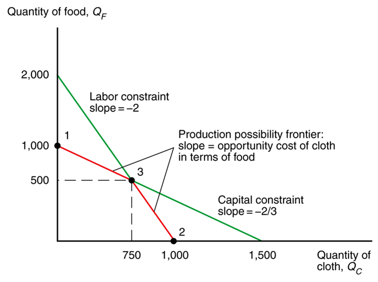

# Production Possibilities

- The opportunity cost of producing one more yard of cloth, in terms of food, is not constant:
  - *low* (2/3 in example) when the economy produces a low amount of cloth and a *high* amount of food
  - *high* (2 in example) when the economy produces a high amount of cloth and a *low* amount of food
- Why? Because when the economy devotes more resources towards production of one good, the marginal productivity of those resources tends to be low so that the opportunity cost is high.

# Production Possibilities

- The above PPF equations do not allow substitution of capital for labor in production.
  - Unit factor requirements are constant along each line segment of the PPF.
- If producers can substitute one input for another in the production process, then the PPF is curved (bowed).
  - Opportunity cost of cloth increases as producers make more cloth.

# The PPF with Factor Substitution

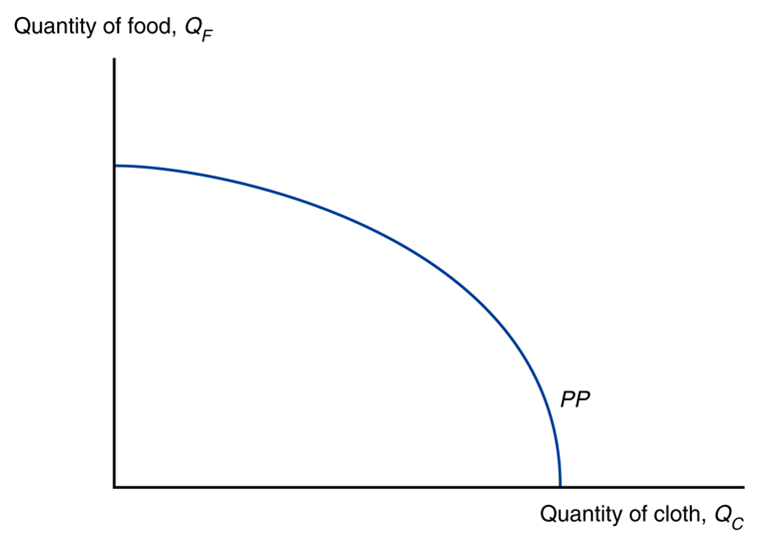

# Production Possibilities

- What does the country produce?
- The economy produces at the point that maximizes the value of production, V.
- An **isovalue** line is a line representing a constant value of production, V: $V = P_C Q_C + P_F Q_F$
  - where $P_C$ and $P_F$ are the prices of cloth and food.
  - slope of isovalue line is – ($P_C/P_F$)

# Prices and Production

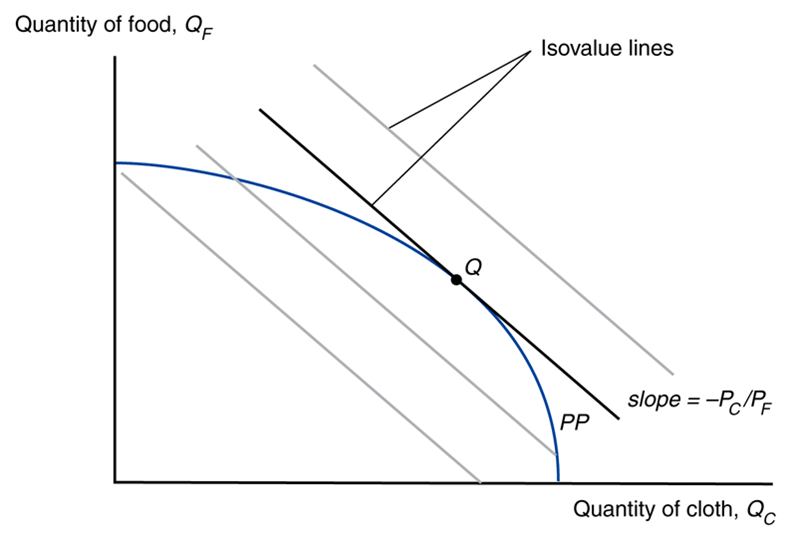

# Production Possibilities

- Given the relative price of cloth, the economy produces at the point Q that touches the highest possible isovalue line.
- At that point, the relative price of cloth equals the slope of the PPF, which equals the opportunity cost of producing cloth.
  - The trade-off in production equals the trade-off according to market prices.

# Choosing the Mix of Inputs

- Producers may choose different amounts of factors of production used to make cloth or food.
- Their choice depends on the wage, w, paid to labor and the rental rate, r, paid when renting capital.
- As the wage w increases relative to the rental rate r, producers use less labor and more capital in the production of both food and cloth.

# Input Possibilities in Food Production

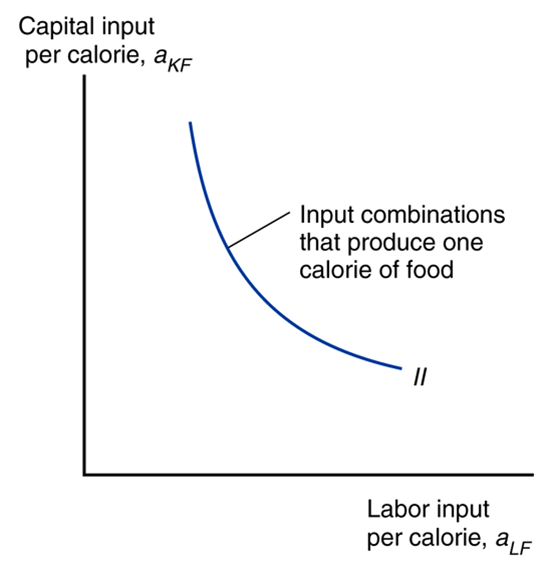

# Choosing the Mix of Inputs

- Assume that at any given factor prices, cloth production uses more labor relative to capital than food production uses: $a_{LC}/a_{KC} > a_{LF}/a_{KF}$ or $L_C/K_C > L_F/K_F$
- Production of cloth is relatively labor intensive, while production of food is relatively land intensive.
- Relative factor demand curve for cloth *CC* lies outside that for food *FF*.

# Factor Prices and Input Choices

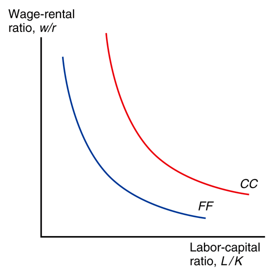

# Factor Prices and Goods Prices

- In competitive markets, the price of a good should equal its cost of production, which depends on the factor prices.
- How changes in the wage and rent affect the cost of producing a good depends on the mix of factors used.
  - An increase in the rental rate of capital should affect the price of food more than the price of cloth since food is the capital intensive industry.
- Changes in $w/r$ are tied to changes in $P_C/P_W$.

# Factor and Goods Prices

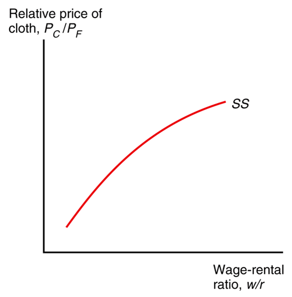

# Factor Prices and Goods Prices

- **Stolper-Samuelson theorem**: If the relative price of a good increases, then the real wage or rental rate of the factor used intensively in the production of that good increases, while the real wage or rental rate of the other factor decreases.
- Any change in the relative price of goods alters the distribution of income.

# From Goods Prices to Input Choices

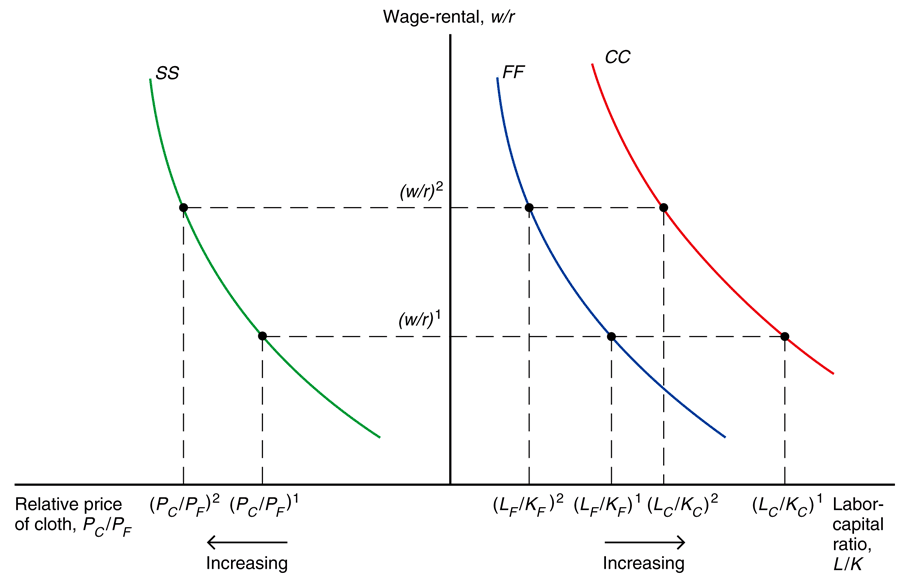

# Factor Prices and Goods Prices

- An increase in the relative price of cloth, $P_C/P_F$, is predicted to
  - raise income of workers relative to that of capital owners, $w/r$.
  - raise the ratio of capital to labor services, $K/L$, used in both industries.
  - raise the real income (purchasing power) of workers and *lower the real income of capital owners.*

# Resources and Output

- How do levels of output change when the economy’s resources change?
- **Rybczynski theorem**: If you hold output prices constant as the amount of a factor of production increases, then the supply of the good that uses this factor intensively increases and the supply of the other good decreases.

# Resources and Output

- Assume an economy’s labor force grows, which implies that its ratio of labor to capital $L/K$ increases.
- Expansion of production possibilities is biased toward cloth.
- At a given relative price of cloth, the ratio of labor to capital used in both sectors remains constant.
- To employ the additional workers, the economy expands production of the relatively labor-intensive good cloth and contracts production of the relatively capital-intensive good food.

# Resources and PPF

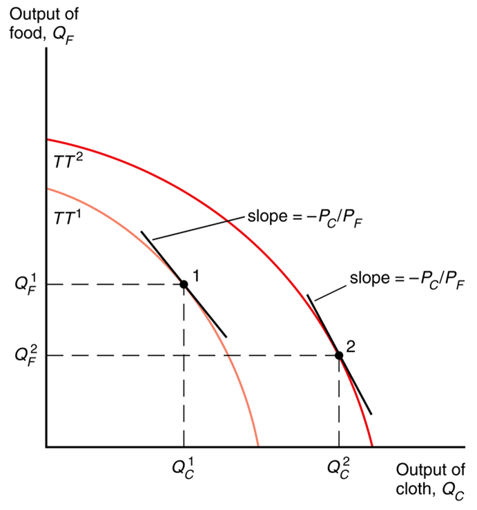

# Resources and Output

- An economy with a *high ratio of labor to capital* produces a *high output of cloth relative to food*.
- Suppose that Home is **relatively abundant** in labor and Foreign in capital: $\frac{L}{K} > \frac{L^*}{K^*}$
  - Likewise, Home is **relatively scarce** in capital and Foreign in labor.
- Home will be relatively efficient at producing cloth because cloth is *relatively labor intensive*.

# Effects of International Trade Between Two-Factor Economies

# Trade in the Heckscher-Ohlin Model

- The countries are assumed to have the same technology and the same tastes.
  - With the same technology, each economy has a comparative advantage in producing the good that relatively intensively uses the factors of production in which the country is relatively well endowed.
  - With the same tastes, the two countries will consume cloth to food in the same ratio when faced with the same relative price of cloth under free trade.

# Trade in the Heckscher-Ohlin Model

- Since cloth is relatively labor intensive, at each relative price of cloth to food, Home will produce a higher ratio of cloth to food than Foreign.
  - Home will have a larger relative supply of cloth to food than Foreign.
  - Home’s relative supply curve lies to the right of Foreign’s.

# Trade Leads to a Convergence of Relative Price

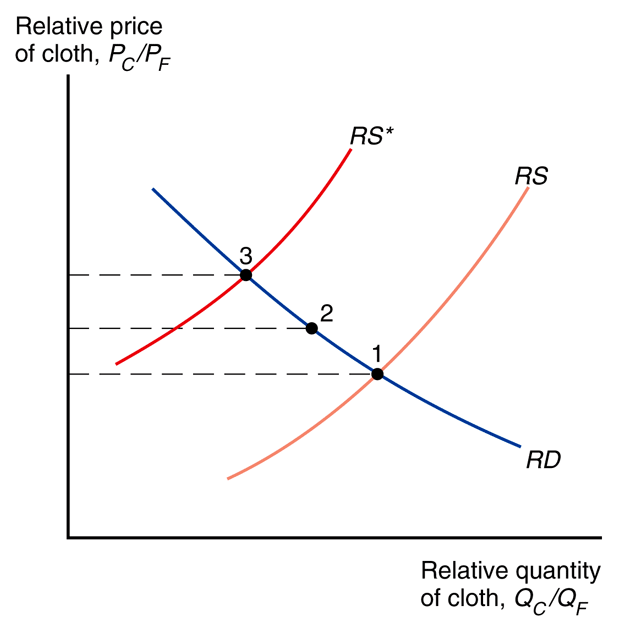

# Trade in the Heckscher-Ohlin Model

- Like the Ricardian model, the Heckscher-Ohlin model predicts a convergence of relative prices with trade.
- With trade, the relative price of cloth rises in the relatively labor abundant (home) country and falls in the relatively labor scarce (foreign) country.

# Trade in the Heckscher-Ohlin Model

- Relative prices and the pattern of trade: In Home, the rise in the relative price of cloth leads to a rise in the relative production of cloth and a fall in relative consumption of cloth.
  - Home becomes an exporter of cloth and an importer of food.
- The decline in the relative price of cloth in Foreign leads it to become an importer of cloth and an exporter of food.

# Trade in the Heckscher-Ohlin Model

- **Heckscher-Ohlin theorem**: An economy has a comparative advantage in producing, and thus will export, goods that are relatively intensive in using its relatively abundant factors of production,
  - and will import goods that are relatively intensive in using its relatively scarce factors of production.

# Factor Price Equalization

- Unlike the Ricardian model, the Heckscher-Ohlin model predicts that factor prices will be equalized among countries that trade.
- Free trade equalizes relative output prices.
- Due to the connection between output prices and factor prices, factor prices are also equalized.
- Trade increases the demand of goods produced by relatively abundant factors, indirectly increasing the demand of these factors, raising the prices of the relatively abundant factors.

# Factor Price Equalization

- In the real world, factor prices are not equal across countries.
- The model assumes that trading countries produce the same goods, but countries may produce different goods if their factor ratios radically differ.
- The model also assumes that trading countries have the same technology, but different technologies could affect the productivities of factors and therefore the wages/rates paid to these factors.

# Comparative International Wage Rates (United States = 100)

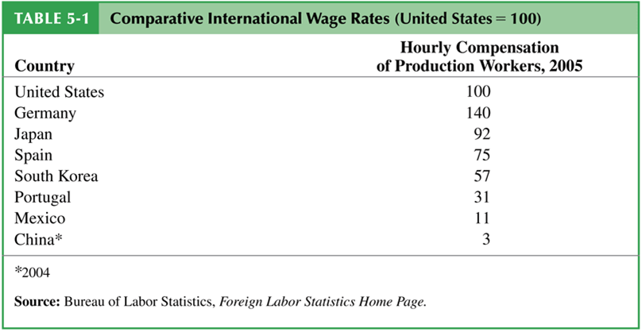

# Factor Price Equalization

- The model also ignores trade barriers and transportation costs, which may prevent output prices and thus factor prices from equalizing.
- The model predicts outcomes for the long run, but after an economy liberalizes trade, factors of production may not quickly move to the industries that intensively use abundant factors.
  - In the short run, the productivity of factors will be determined by their use in their current industry, so that their wage/rental rate may vary across countries.

# Does Trade Increase Income Inequality?

- Over the last 40 years, countries like South Korea, Mexico, and China have exported to the U.S. goods intensive in unskilled labor (ex., clothing, shoes, toys, assembled goods).
- At the same time, income inequality has increased in the U.S., as wages of unskilled workers have grown slowly compared to those of skilled workers.
- Did the former trend cause the latter trend?

# Does Trade Increase Income Inequality?

- The Heckscher-Ohlin model predicts that owners of relatively abundant factors will gain from trade and owners of relatively scarce factors will lose from trade.
  - Little evidence supporting this prediction exists.
1. According to the model, a change in the distribution of income occurs through changes in output prices, but there is no evidence of a change in the prices of skill-intensive goods relative to prices of unskilled-intensive goods.

# Does Trade Increase Income Inequality?

2. According to the model, wages of unskilled workers should increase in unskilled labor abundant countries relative to wages of skilled labor, but in some cases the reverse has occurred:
   - Wages of skilled labor have increased more rapidly in Mexico than wages of unskilled labor.
     - But compared to the U.S. and Canada, Mexico is supposed to be abundant in unskilled workers.
3. Even if the model were exactly correct, trade is a small fraction of the U.S. economy, so its effects on U.S. prices and wages prices should be small.

# Trade and Income Distribution

- Changes in income distribution occur with every economic change, not only international trade.
  - Changes in technology, changes in consumer preferences, exhaustion of resources and discovery of new ones all affect income distribution.
  - Economists put most of the blame on technological change and the resulting premium paid on education as the major cause of increasing income inequality in the US.
- It would be better to compensate the losers from trade (or any economic change) than prohibit trade.
  - The economy as a whole does benefit from trade.

# Trade and Income Distribution

- There is a political bias in trade politics: potential losers from trade are better politically organized than the winners from trade.
  - Losses are usually concentrated among a few, but gains are usually dispersed among many.
  - Each of you pays about $8/year to restrict imports of sugar, and the total cost of this policy is about $2 billion/year.
  - The benefits of this program total about $1 billion, but this amount goes to relatively few sugar producers.

# Empirical Evidence on the Heckscher-Ohlin Model

# Empirical Evidence on the Heckscher-Ohlin Model

- Tests on US data
  - Leontief found that U.S. exports were less capital-intensive than U.S. imports, even though the U.S. is the most capital-abundant country in the world: **Leontief paradox**.
- Tests on global data
  - Bowen, Leamer, and Sveikauskas tested the Heckscher-Ohlin model on data from 27 countries and confirmed the Leontief paradox on an international level.

# Factor Content of U.S. Exports and Imports for 1962

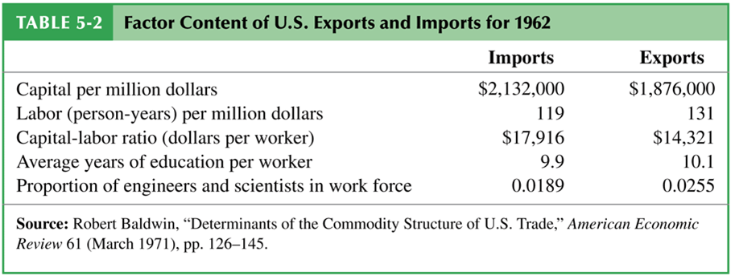

# Testing the Heckscher-Ohlin Model

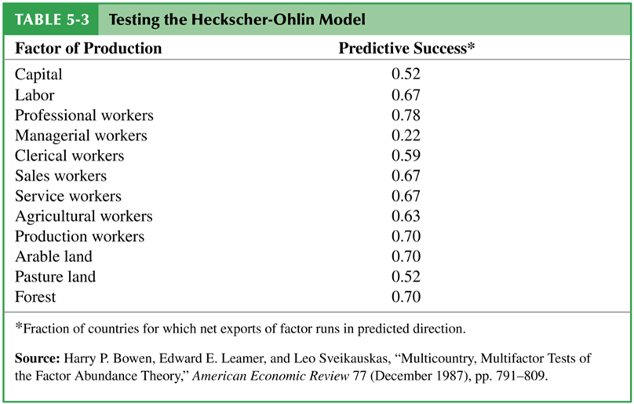

# Empirical Evidence on the Heckscher-Ohlin Model

- Because the Heckscher-Ohlin model predicts that factor prices will be equalized across trading countries, it also predicts that factors of production will produce and export a certain quantity goods until factor prices are equalized.
  - In other words, a predicted value of services from factors of production will be *embodied* in a predicted volume of trade between countries.

# Empirical Evidence on the Heckscher-Ohlin Model

- But because factor prices are not equalized across countries, the predicted volume of trade is much larger than actually occurs.
  - A result of “missing trade” discovered by Daniel Trefler.
- The reason for this “missing trade” appears to be the assumption of identical technology among countries.
  - Technology affects the productivity of workers and therefore the value of labor services.
  - A country with high technology and a high value of labor services would not necessarily import a lot from a country with low technology and a low value of labor services.

# Estimated Technological Efficiency, 1983 (United States = 1)

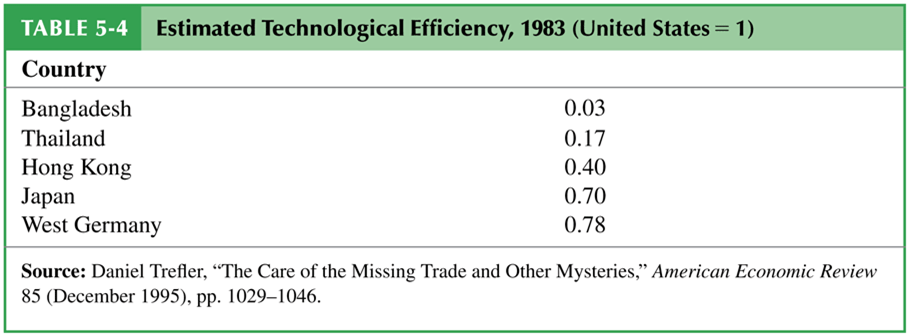

# Empirical Evidence on the Heckscher-Ohlin Model

- Looking at changes in patterns of exports between developed (high income) and developing (low/middle income) countries supports the theory.
- US imports from Bangladesh are highest in low-skill-intensity industries, while US imports from Germany are highest in high- skill-intensity industries.

# Skill Intensity and the Pattern of U.S. Imports from Two Countries

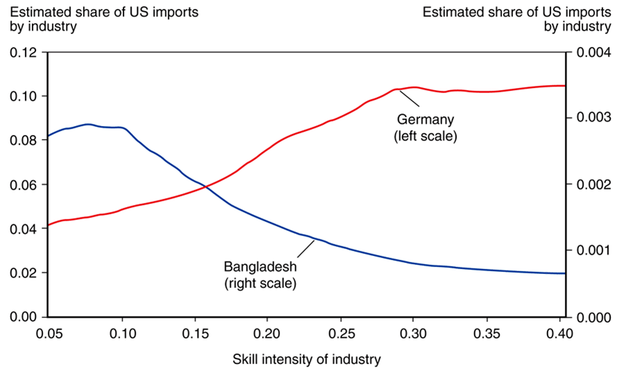

# Empirical Evidence on the Heckscher-Ohlin Model

- As Japan and the four Asian “miracle” countries became more skill-abundant, U.S. imports from these countries shifted from less skill-intensive industries toward more skill-intensive industries.

# Changing Patterns of Comparative Advantage

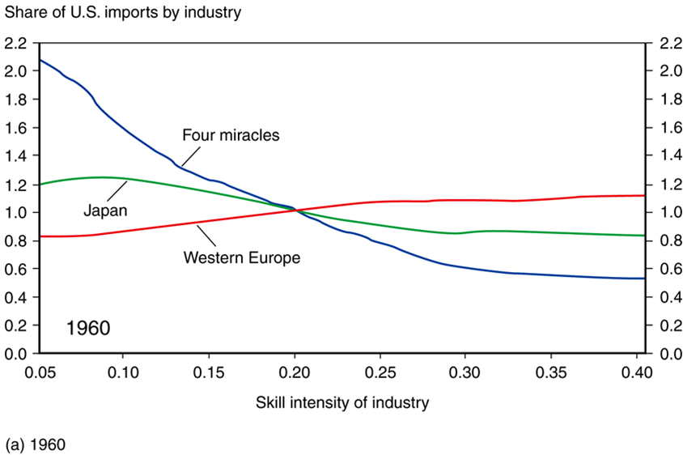

# Changing Patterns of Comparative Advantage

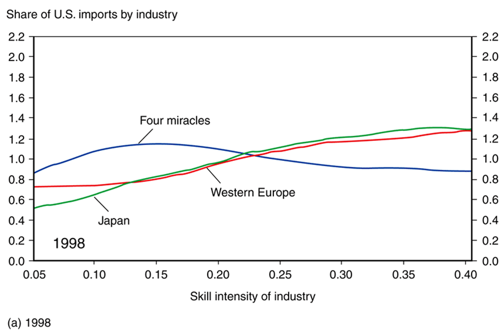

# Summary

# Summary

1. Substitution of factors used in the production process generates a curved PPF.
   - When an economy produces a low quantity of a good, the opportunity cost of producing that good is low.
   - When an economy produces a high quantity of a good, the opportunity cost of producing that good is high.
2. When an economy produces the most value it can from its resources, the opportunity cost of producing a good equals the relative price of that good in markets.

# Summary

3. An increase in the relative price of a good causes the real wage or real rental rate of the factor used intensively in the production of that good to increase,
   - while the real wage and real rental rates of other factors of production decrease.
4. If output prices remain constant as the amount of a factor of production increases, then the supply of the good that uses this factor intensively increases, and the supply of the other good decreases.

# Summary

5. An economy exports goods that are relatively intensive in its relatively abundant factors of production and imports goods that are relatively intensive in its relatively scarce factors of production.
6. Owners of abundant factors gain, while owners of scarce factors lose with trade.
7. A country as a whole is predicted to be better off with trade, so winners could in theory compensate the losers within each country.

# Summary

8. The Heckscher-Ohlin model predicts that relative output prices and factor prices will equalize, neither of which occurs in the real world.
9. Empirical support of the Heckscher-Ohlin model is weak except for cases involving trade between high-income countries and low/middle- income countries or when technology differences are included.